# Assignment - Reproducible Workflows

1753320 - 2030071

Tycho Brouwer and Romée Simons

2024-03-18

# Task 1

## Tycho Brouwer

### Education

- VWO NT&NG **(2015-2021)**
- Bsc. Mechanical Engineering @ TU/e **(2021-now)**

### Employment

- Sailing instructor **(2018-2023)**

### Hobbies

- Badminton at Panache
- Homelab tickering
- Programming

## Romée Simons

### Education

- Gymnasium EM **(2018-2023)**
- Pre University College @ University of Leiden **(2021-2023)**
- Bsc. Psychology & Technology @ TU/e **(2023-now)**

### Employment

- Ice cream shop **(summer 2023)**
- Tutoring high school subjects **(2020-2023)**
- Lyceo tutor **(2024-now)**

### Hobbies

- Reading
- Rowing and Running
- Spending time with friends & family

# Task 2

To generate normally distributed values use the `rnorm(n, mean, std)` function from the `stats` package.

```
##  [1]  0.4942309 -0.3311662  2.2061880  0.4263875 -1.5204645  0.4844455
##  [7]  0.8231649 -0.1874053 -1.4741733 -1.7132470 -0.5766938 -0.6618661
## [13]  1.3834697 -0.8225906  0.1508204
```

# Task 3

To add a footnote you can type ‘^’ followed by text in square brackets ‘[]’ [^1]

A horizontal rule can be added by typing `---`

> A blockquote can be added by typing the ‘>’ directly followed by the quote.

# Task 4

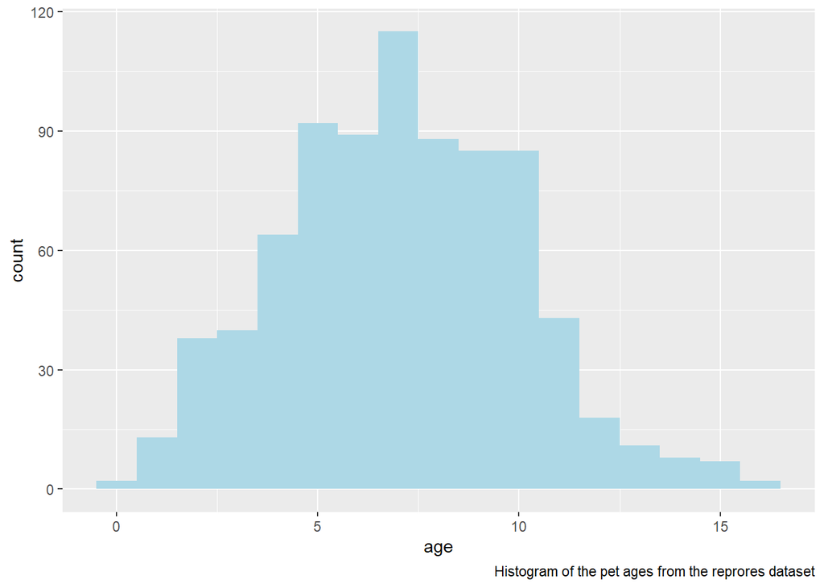

```r
data("pets", package = "reprores")
ggplot(pets, aes(age)) +
  geom_histogram(binwidth = 1, fill = "lightblue") +
  labs(
    caption = "Histogram of the pet ages from the reprores dataset"
  )
```

# Task 5

To read the data, use the function `read_csv()` from the `tidyverse` package. To calculate the average use the function `mean()`.

The average age of the pets is 7.08.

# Task 6

Table 1: Summary statistics for the pets dataset.

| Country | N | Means Weight | Means Age |
| --- | --- | --- | --- |
| NL | 400 | 12.96 | 7.09 |
| UK | 400 | 14.33 | 7.07 |

# Task 7

Do not forget to include hobbies in task number 1. The above was made using the Rmarkdown package (Baumer & Udwin, 2015).

Baumer, B., & Udwin, D. (2015). R markdown. *Wiley Interdisciplinary Reviews: Computational Statistics*, *7*(3), 167–177.

[^1]: This is a footnote for task 3